# World Happiness Report

## Reading and binding the datasets

The data is provided in 5 datasets, one per year (2015-2019).

```r
library(tidyverse)
library(knitr)

files <- list.files("data", pattern = "*.csv", full.names = TRUE)
data_list <- sapply(files, read_csv)

data_list$`data/2018.csv` <- data_list$`data/2018.csv` %>%
     mutate(`Perceptions of corruption` = as.numeric(`Perceptions of corruption`))

data <- bind_rows(data_list, .id = "year")
data$year <- gsub("\\D", "", x = data$year) %>% as.numeric()
```

## Merging corresponding variables together

Many corresponding variables are named differently across the original datasets, so there is some tidying to be done.

```r
hrep <- data %>%
     mutate(gdp_pc = rowSums(data[, c("Economy (GDP per Capita)",
                                      "Economy..GDP.per.Capita.",
                                      "GDP per capita")],
                             na.rm = TRUE)) %>%
     select(-c("Economy (GDP per Capita)",
               "Economy..GDP.per.Capita.",
               "GDP per capita")) %>%
     mutate(happiness_rank = rowSums(data[, c("Happiness Rank",
                                              "Happiness.Rank",
                                              "Overall rank")],
                                     na.rm = TRUE)) %>%
     select(-c("Happiness Rank",
               "Happiness.Rank",
               "Overall rank")) %>%
     mutate(happiness_score = rowSums(data[, c("Happiness Score",
                                               "Happiness.Score",
                                               "Score")],
                                      na.rm = TRUE)) %>%
     select(-c("Happiness Score",
               "Happiness.Score",
               "Score")) %>%
     mutate(health_life_exp = rowSums(data[, c("Health (Life Expectancy)",
                                               "Health..Life.Expectancy.",
                                               "Healthy life expectancy")],
                                      na.rm = TRUE)) %>%
     select(-c("Health (Life Expectancy)",
               "Health..Life.Expectancy.",
               "Healthy life expectancy")) %>%
     mutate(corruption = rowSums(data[, c("Trust (Government Corruption)",
                                          "Trust..Government.Corruption.",
                                          "Perceptions of corruption")],
                                 na.rm = TRUE)) %>%
     select(-c("Trust (Government Corruption)",
               "Trust..Government.Corruption.",
               "Perceptions of corruption")) %>%
     mutate(freedom = rowSums(data[, c("Freedom",
                                       "Freedom to make life choices")],
                              na.rm = TRUE)) %>%
     select(-c("Freedom",
               "Freedom to make life choices")) %>%
     mutate(dystopia_residual = rowSums(data[, c("Dystopia Residual",
                                                 "Dystopia.Residual")],
                                        na.rm = TRUE)) %>%
     select(-c("Dystopia Residual",
               "Dystopia.Residual")) %>%

     # the following step is legitimate because there are only countries in "country or region"
     mutate(country = ifelse(is.na(Country), `Country or region`, Country)) %>%
     select(-c(Country, `Country or region`)) %>%

     # dropping the following columns because
     # (a) only one dataset indicates the Standard Error and
     # (b) the nature of the confidence intervals is uncertain (even though it is probably +/- 1 SE)
     select(-c("Standard Error",
               "Upper Confidence Interval",
               "Lower Confidence Interval",
               "Whisker.low",
               "Whisker.high")) %>%

     # consistent names
     rename(region = Region,
            social_support = "Social support",
            family = Family,
            generosity = Generosity)
```

## Exploring the data

### What are the top 10 happiest countries overall?

```r
hrep %>%
  group_by(country) %>%
  summarise(hp_avg = round(mean(happiness_score), 2)) %>%
  arrange(desc(hp_avg)) %>%
  top_n(10) %>%
  kable()
```

| country | hp_avg |
| --- | --- |
| Denmark | 7.55 |
| Finland | 7.54 |
| Norway | 7.54 |
| Iceland | 7.51 |
| Switzerland | 7.51 |
| Netherlands | 7.40 |
| Canada | 7.35 |
| Sweden | 7.32 |
| New Zealand | 7.31 |
| Australia | 7.28 |

### What countries’ happiness scores changed most across the 5 years?

```r
highvar_countries <- hrep %>%
  group_by(country) %>%
  summarise(hp_var = var(happiness_score)) %>%
  arrange(desc(hp_var)) %>%
  top_n(5)

highvar_countries %>%
  kable()
```

| country | hp_var |
| --- | --- |
| Venezuela | 0.8063028 |
| Benin | 0.3925175 |
| Lesotho | 0.2981240 |
| Ivory Coast | 0.2816667 |
| Togo | 0.2643032 |

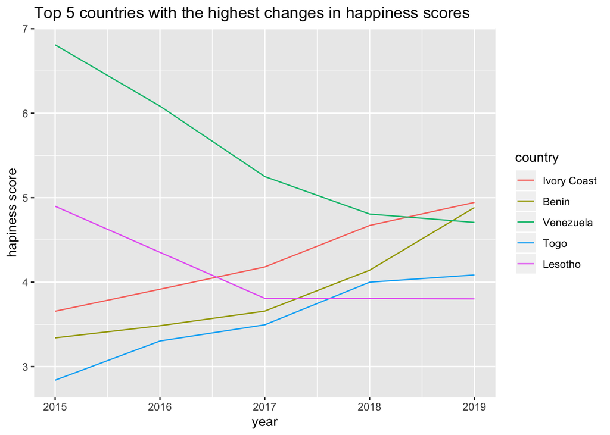

```r
hrep %>%
  filter(country %in% highvar_countries$country) %>%
  ggplot(aes(x = year, y = happiness_score,
             col = fct_reorder2(country, year, happiness_score))) +
  geom_line() +
  labs(y = "hapiness score", col = "country",
       title = "Top 5 countries with the highest changes in happiness scores")
```

### Variables associated with happiness score

Let’s look at the variables associated with the happiness score. In this dataset, they are represented in a somewhat peculiar way. According to the description on Kaggle the variables add up to the happiness score and represent the “extent to which these factors contribute in evaluating the happiness in each country”.

First of all, let’s check if the first statement holds true. Do the variables add up to the happiness score?

```r
hrep_checksums <- tibble(scores = hrep$happiness_score,
           sums = rowSums(hrep[, c("family", "generosity", "social_support", "gdp_pc", "corruption", "freedom", "dystopia_residual")], na.rm = TRUE))

head(hrep_checksums)
```

```
## # A tibble: 6 x 2
##   scores  sums
##    <dbl> <dbl>
## 1   7.59  6.65
## 2   7.56  6.61
## 3   7.53  6.65
## 4   7.52  6.64
## 5   7.43  6.52
## 6   7.41  6.52
```

As can be seen at the top of the dataset there are at least some cases where the variables do not add up to the happiness score. Does this apply to other cases as well?

```r
mean(hrep_checksums$scores == hrep_checksums$sums)
```

```
## [1] 0
```

It turns out the variables never add up to the happiness score. Are we missing a variable, which could be the case if the sum is always smaller than the score?

```r
mean(hrep_checksums$sums < hrep_checksums$scores)
```

```
## [1] 0.9974425
```

In the vast majority of cases, the actual score is larger than the sum. Let’s look at the exceptions:

```r
hrep_checksums %>%
  slice(which(hrep_checksums$scores < hrep_checksums$sums)) %>%
  kable()
```

| scores | sums |
| --- | --- |
| 4.507 | 4.507180 |
| 3.808 | 3.808205 |

In the two exceptions the variables almost add up to the happiness score.

Let’s look at the average difference between the sums and the scores.

```r
mean(hrep_checksums$scores - hrep_checksums$sums)
```

```
## [1] 1.371865
```

## Conclusion

Overall, there is a substantial difference between the happiness scores and the sums of the explaining variables. Accordingly, the statement about the explaining variables’ scales does not hold true. This prevents further analyses as we cannot be certain about the nature and composition of these variables. In a real-world scenario, one might want to gather further information on the way the data was gathered and the variables were computed.